# passerella quality control

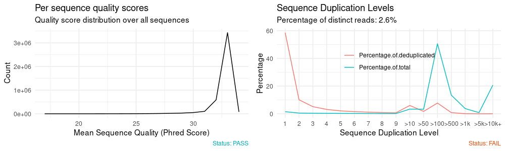

[1] “QC results for sample P_iliaca_42685_fastqc.zip”

| Measure | Value |
| --- | --- |
| Filename | P_iliaca_42685.fq |
| File type | Conventional base calls |
| Encoding | Sanger / Illumina 1.9 |
| Total Sequences | 1417208 |
| Sequences flagged as poor quality | 0 |
| Sequence length | 95 |
| %GC | 37 |

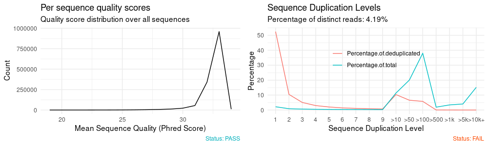

[1] “QC results for sample P_iliaca_44466_fastqc.zip”

| Measure | Value |
| --- | --- |
| Filename | P_iliaca_44466.fq |
| File type | Conventional base calls |
| Encoding | Sanger / Illumina 1.9 |
| Total Sequences | 1643335 |
| Sequences flagged as poor quality | 0 |
| Sequence length | 95 |
| %GC | 37 |

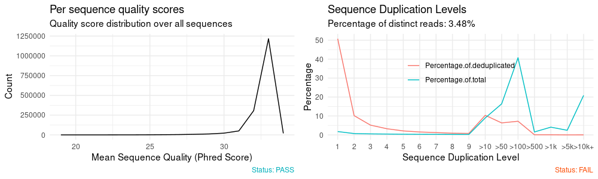

[1] “QC results for sample P_iliaca_80673_fastqc.zip”

| Measure | Value |
| --- | --- |
| Filename | P_iliaca_80673.fq |
| File type | Conventional base calls |
| Encoding | Sanger / Illumina 1.9 |
| Total Sequences | 1620518 |
| Sequences flagged as poor quality | 0 |
| Sequence length | 95 |
| %GC | 36 |

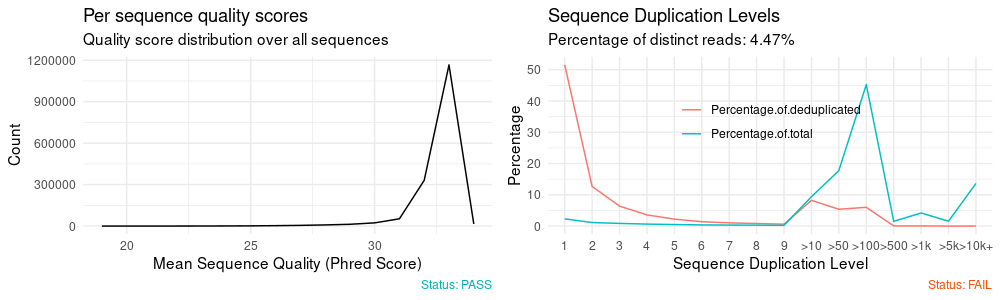

[1] “QC results for sample P_iliaca_80686_fastqc.zip”

| Measure | Value |
| --- | --- |
| Filename | P_iliaca_80686.fq |
| File type | Conventional base calls |
| Encoding | Sanger / Illumina 1.9 |
| Total Sequences | 1886624 |
| Sequences flagged as poor quality | 0 |
| Sequence length | 95 |
| %GC | 37 |

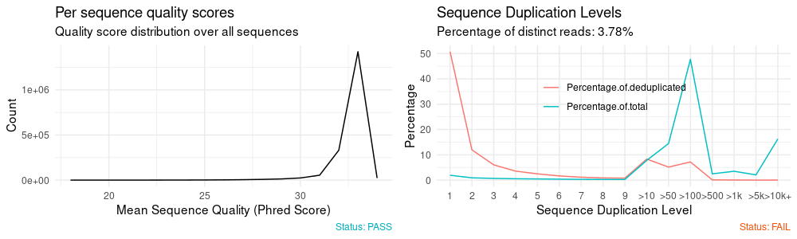

[1] “QC results for sample S_arborea_35787_fastqc.zip”

| Measure | Value |
| --- | --- |
| Filename | S_arborea_35787.fq |
| File type | Conventional base calls |
| Encoding | Sanger / Illumina 1.9 |
| Total Sequences | 304083 |
| Sequences flagged as poor quality | 0 |
| Sequence length | 95 |
| %GC | 37 |

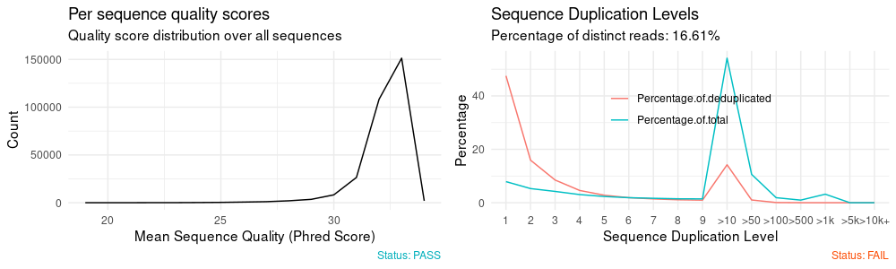

[1] “QC results for sample Z_querula_26548_fastqc.zip”

| Measure | Value |
| --- | --- |
| Filename | Z_querula_26548.fq |
| File type | Conventional base calls |
| Encoding | Sanger / Illumina 1.9 |
| Total Sequences | 478329 |
| Sequences flagged as poor quality | 0 |
| Sequence length | 95 |
| %GC | 37 |

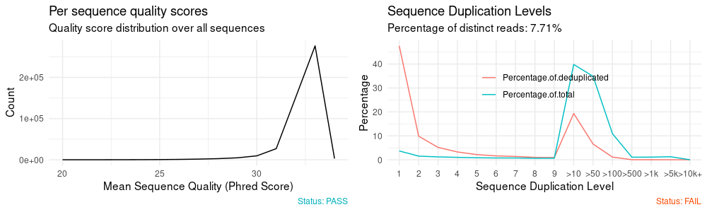

```r
#aggregate the reports by pointing this function to the folder holding output of fastqc()
qc <- qc_aggregate(qc.dir, progressbar = F)

#stats per sample
knitr::kable(qc_stats(qc))
```

| sample | pct.dup | pct.gc | tot.seq | seq.length |
| --- | --- | --- | --- | --- |
| P_iliaca_119300.fq | 96.64 | 37 | 2696625 | 95 |
| P_iliaca_119384.fq | 90.90 | 38 | 556561 | 95 |
| P_iliaca_119875.fq | 81.67 | 38 | 93014 | 95 |
| P_iliaca_119926.fq | 96.06 | 37 | 1550233 | 95 |
| P_iliaca_14936.fq | 85.24 | 36 | 126777 | 95 |
| P_iliaca_20392.fq | 95.39 | 38 | 972703 | 95 |
| P_iliaca_27545.fq | 61.18 | 38 | 23465 | 95 |
| P_iliaca_30340.fq | 92.21 | 36 | 310991 | 95 |
| P_iliaca_30343.fq | 97.17 | 37 | 3152635 | 95 |
| P_iliaca_31497.fq | 96.56 | 37 | 2132136 | 95 |
| P_iliaca_34095.fq | 97.36 | 37 | 4296206 | 95 |
| P_iliaca_34099.fq | 96.82 | 37 | 2313352 | 95 |
| P_iliaca_34110.fq | 93.85 | 37 | 917283 | 95 |
| P_iliaca_34528.fq | 80.23 | 38 | 83981 | 95 |
| P_iliaca_36901.fq | 94.74 | 37 | 835004 | 95 |
| P_iliaca_37204.fq | 96.31 | 37 | 1656767 | 95 |
| P_iliaca_37207.fq | 95.98 | 37 | 1464177 | 95 |
| P_iliaca_37210.fq | 92.79 | 38 | 523259 | 95 |
| P_iliaca_37506.fq | 89.23 | 38 | 153797 | 95 |
| P_iliaca_37508.fq | 83.83 | 37 | 38512 | 95 |
| P_iliaca_37552.fq | 64.93 | 36 | 4169 | 95 |
| P_iliaca_38225.fq | 91.94 | 36 | 448299 | 95 |
| P_iliaca_38230.fq | 93.65 | 37 | 572055 | 95 |
| P_iliaca_38815.fq | 95.58 | 37 | 2234610 | 95 |
| P_iliaca_38937.fq | 94.61 | 37 | 724799 | 95 |
| P_iliaca_40396.fq | 94.74 | 37 | 826920 | 95 |
| P_iliaca_40401.fq | 88.54 | 37 | 211314 | 95 |
| P_iliaca_40407.fq | 96.79 | 37 | 2781624 | 95 |
| P_iliaca_41097.fq | 97.40 | 37 | 4339464 | 95 |
| P_iliaca_42685.fq | 95.81 | 37 | 1417208 | 95 |
| P_iliaca_44466.fq | 96.52 | 37 | 1643335 | 95 |
| P_iliaca_80673.fq | 95.53 | 36 | 1620518 | 95 |
| P_iliaca_80686.fq | 96.22 | 37 | 1886624 | 95 |
| S_arborea_35787.fq | 83.39 | 37 | 304083 | 95 |
| Z_querula_26548.fq | 92.29 | 37 | 478329 | 95 |

### solid red line = median sample value

### dashed red line = 10% of median sample value

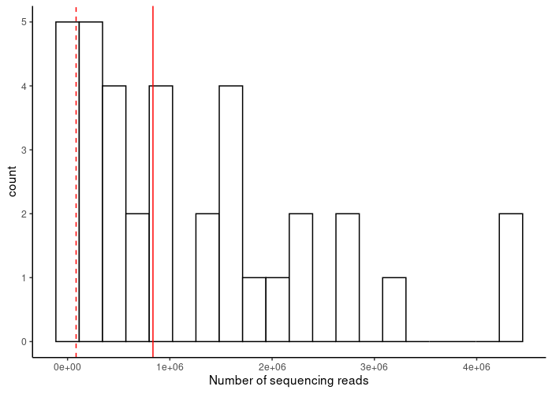

```r
#save stats info as an object
stats.info<-qc_stats(qc)
#make tot.seq numeric
stats.info$tot.seq<-as.numeric(stats.info$tot.seq)

#make histogram of number of sequence reads for each sample
ggplot(stats.info, aes(x=tot.seq))+
              geom_histogram(color="black", fill="white", bins=20)+
              geom_vline(aes(xintercept=median(tot.seq)), color = "red")+
              geom_vline(aes(xintercept=median(tot.seq)*.1), color = "red", lty=14)+
              theme_classic()+
              xlab("Number of sequencing reads")
```

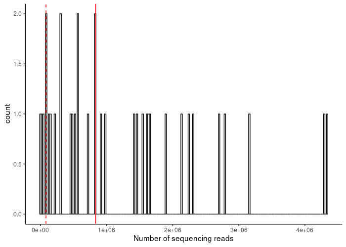

```r
#solid red line = median sample value
#dashed red line = 10% of median sample value
ggplot(stats.info, aes(x=tot.seq))+
              geom_histogram(color="black", fill="white", bins=200)+
              geom_vline(aes(xintercept=median(tot.seq)), color = "red")+
              geom_vline(aes(xintercept=median(tot.seq)*.1), color = "red", lty=14)+
              theme_classic()+
              xlab("Number of sequencing reads")
```

```r
#show me the samples that have less than 10% of the number of reads as the median sample from this experiment (these should be dropped immediately)
print(paste("Median sample contains", median(stats.info$tot.seq), "reads. The following samples contain less than", median(stats.info$tot.seq)*.1, "reads (10% of the median), and should likely be dropped"))
```

[1] “Median sample contains 835004 reads. The following samples contain less than 83500.4 reads (10% of the median), and should likely be dropped”

```r
knitr::kable(stats.info[stats.info$tot.seq < median(stats.info$tot.seq)*.1,])
```

| sample | pct.dup | pct.gc | tot.seq | seq.length |
| --- | --- | --- | --- | --- |
| P_iliaca_27545.fq | 61.18 | 38 | 23465 | 95 |
| P_iliaca_37508.fq | 83.83 | 37 | 38512 | 95 |
| P_iliaca_37552.fq | 64.93 | 36 | 4169 | 95 |